# Hand-foot-and-mouth disease

## Constants

The data are in this folder:

```r
oned <- "~/Library/CloudStorage/OneDrive-OxfordUniversityClinicalResearchUnit/"
data_folder <- paste0(oned, "GitHub/OUCRU-Modelling/hfmd/")
```

## Packages

Make sure that all the package listed below are installed. If a package (e.g. `tidyr`) is not installed, install it by typing `install.packages("tidyr")` at the command line.

```r
library(readxl)
library(dplyr)
library(stringr)
library(purrr)
library(tidyr)
library(lubridate)
library(magrittr)
library(mgcv)
```

## Functions

A function that reads the excel files:

```r
read_excel2 <- function(x, ...) {
  out <- readxl::read_excel(paste0(data_folder, x), skip = 1, ...)
  out |>
    names() |>
    str_remove("^.*\r*\n\\(") |>
    str_remove("\\)") |>
    str_replace("...12", "month") |>
    str_replace("...13", "year") %>%
    setNames(out, .) |>
    filter(! is.na(Participant_No))
}
```

A tuning of the `polygon()` function:

```r
polygon2 <- function(x, y1, y2, ...) {
  polygon(c(x, rev(x)), c(y1, rev(y2)), ...)
}
```

The function that performs a likelihood ratio test:

```r
lrt <- function(...) anova(..., test = "LRT")
```

A tuning of the `points()` function:

```r
points2 <- function(...) points(..., pch = "|", cex = .5)
```

A tuning of the `mgcv::gam()` function:

```r
gam2 <- function(formula, family = gaussian(), data = list(), ...){
  out <- mgcv::gam(formula, family, data, ...)
  out$data <- data
  out
}
```

A function that extracts model quality metrics from a `gam` object:

```r
quality <- function(x) {
  tibble(deviance = deviance(x),
         AIC      = AIC(x),
         GCV      = x$gcv.ubre)
}
```

A function that adds a column (in first position) to a tibble to inform about the type of smoothing that was applied:

```r
add_smooth_col <- function(x, s) {
  bind_cols(tibble(smooth = s), x)
}
```

A function that extracts p values from an `anova` object (run on a `gam` object):

```r
p_values <- function(x) {
  tibble(year     = x$p.table[2, "Pr(>|z|)"],
         "s(age)" = x$s.table[1, "p-value"])
}
```

## Loading data

```r
sero <- data_folder |>
  dir() |>
  map_dfr(read_excel2) |>
  mutate(across(Neutralization, ~ .x == "Yes")) |>
  replace_na(list(Neutralization = FALSE)) |>
  mutate(collection_date =
           ymd(paste(year, month, `Day of taking blood sample`, sep = ":"))) |>
  select(- `Day of taking blood sample`) |>
  mutate(across(`Serum dilution`, ~ str_remove(.x, "1:") |> as.integer())) |>
  rename(age = `Exact age calculated`, neutralization = Neutralization)
```

The data look like this:

```r
sero
```

```
## # A tibble: 150 × 15
##    Participant_No Province Hospital_name Site_code Collection_No Sample_ID
##    <chr>          <chr>    <chr>         <chr>     <chr>         <chr>
##  1 0001           HCMC     BV Nhi đồng 1 001       06            20FL-001-060001
##  2 0002           HCMC     BV Nhi đồng 1 001       06            20FL-001-060002
##  3 0003           HCMC     BV Nhi đồng 1 001       06            20FL-001-060003
##  4 0004           HCMC     BV Nhi đồng 1 001       06            20FL-001-060004
##  5 0005           HCMC     BV Nhi đồng 1 001       06            20FL-001-060005
##  6 0006           HCMC     BV Nhi đồng 1 001       06            20FL-001-060006
##  7 0007           HCMC     BV Nhi đồng 1 001       06            20FL-001-060007
##  8 0008           HCMC     BV Nhi đồng 1 001       06            20FL-001-060008
##  9 0009           HCMC     BV Nhi đồng 1 001       06            20FL-001-060009
## 10 0010           HCMC     BV Nhi đồng 1 001       06            20FL-001-060010
## # ℹ 140 more rows
## # ℹ 9 more variables: `Serum/plasma` <chr>, Age_group <chr>,
## #   `Age labelled on tubes` <chr>, age <dbl>, month <chr>, year <chr>,
## #   `Serum dilution` <int>, neutralization <lgl>, collection_date <date>
```

and the next 6 variables:

```r
sero[-(1:7)]
```

```
## # A tibble: 150 × 8
##    Age_group `Age labelled on tubes`    age month year  `Serum dilution`
##    <chr>     <chr>                    <dbl> <chr> <chr>            <int>
##  1 0≤ & <1   0                       0.370  12    2022                NA
##  2 0≤ & <1   0                       0.332  12    2022                NA
##  3 0≤ & <1   0                       0.0767 1     2023                NA
##  4 0≤ & <1   0                       0.438  12    2022                NA
##  5 0≤ & <1   0                       0.932  1     2023                NA
##  6 1≤ & <2   1                       1.96   12    2022                16
##  7 1≤ & <2   1                       1.40   12    2022                NA
##  8 1≤ & <2   1                       1.07   12    2022                NA
##  9 1≤ & <2   1                       1.71   12    2022                NA
## 10 1≤ & <2   1                       1.92   12    2022                NA
## # ℹ 140 more rows
## # ℹ 2 more variables: neutralization <lgl>, collection_date <date>
```

and the last 2 variables:

```r
sero[-(1:13)]
```

```
## # A tibble: 150 × 2
##    neutralization collection_date
##    <lgl>          <date>
##  1 FALSE          2022-12-28
##  2 FALSE          2022-12-27
##  3 FALSE          2023-01-04
##  4 FALSE          2022-12-27
##  5 FALSE          2023-01-03
##  6 TRUE           2022-12-26
##  7 FALSE          2022-12-26
##  8 FALSE          2022-12-27
##  9 FALSE          2022-12-06
## 10 FALSE          2022-12-27
## # ℹ 140 more rows
```

## A polynomial logistic model

A function that computes a model’s predictions:

```r
predict2 <- function(x, ci = .95, le = 512, m = 100) {
  p <- (1 - ci) / 2

  link_inv <- x$family$linkinv
  dataset <- x$data
  n <- nrow(dataset) - length(x$coefficients)
  age_range <- range(dataset$age)

  ages <- seq(age_range[1], age_range[2], le = le)

  x |>
    predict(data.frame(age = ages), se.fit = TRUE) |>
    extract(c("fit", "se.fit")) %>%
    c(age = list(ages), .) |>
    as_tibble() |>
    mutate(lwr = m * link_inv(fit + qt(    p, n) * se.fit),
           upr = m * link_inv(fit + qt(1 - p, n) * se.fit),
           fit = m * link_inv(fit)) |>
    select(- se.fit)
}
```

A function that plots a model’s predictions:

```r
plot_predictions <- function(x, add = FALSE, col = 4, alpha = .2, lwd = 2,
                             m = 100) {
  with(x, {
    if (! add) {
      plot(NA, xlim = c(0, max(age)), ylim = c(0, m),
           xlab = "age (year)", ylab = "seroprevalence (%)")
    }
    polygon2(age, lwr, upr, border = NA, col = adjustcolor(col, alpha))
    lines(age, fit, col = col, lwd = lwd)
  })
}
```

A function that generates a polynomial formula:

```r
make_formula <- function(degree) {
  2:degree |>
    map_chr(~ paste("I(age ^", .x, ")")) |>
    paste(collapse = " + ") %>%
    paste("neutralization ~ age +", .) |>
    as.formula()
}
```

A function that helps looking for the optimal degree of the polynomial:

```r
test_degrees <- function(yr, degree) {
  degree |>
    make_formula() |>
    glm(binomial, filter(sero, year == as.character(yr))) |>
    lrt()
}
```

Looking for optimal degrees for the 2 years:

```r
test_degrees(2022, 5)
```

```
## Analysis of Deviance Table
##
## Model: binomial, link: logit
##
## Response: neutralization
##
## Terms added sequentially (first to last)
##
##
##          Df Deviance Resid. Df Resid. Dev  Pr(>Chi)
## NULL                        70     92.122
## age       1  13.1564        69     78.965 0.0002865 ***
## I(age^2)  1   0.7393        68     78.226 0.3898802
## I(age^3)  1   0.0001        67     78.226 0.9930642
## I(age^4)  1   0.4715        66     77.754 0.4922871
## I(age^5)  1   1.1410        65     76.613 0.2854348
## ---
## Signif. codes:  0 '***' 0.001 '**' 0.01 '*' 0.05 '.' 0.1 ' ' 1
```

```r
test_degrees(2023, 5)
```

```
## Analysis of Deviance Table
##
## Model: binomial, link: logit
##
## Response: neutralization
##
## Terms added sequentially (first to last)
##
##
##          Df Deviance Resid. Df Resid. Dev  Pr(>Chi)
## NULL                        78    108.490
## age       1  14.4660        77     94.024 0.0001427 ***
## I(age^2)  1   7.6539        76     86.370 0.0056650 **
## I(age^3)  1   1.1367        75     85.233 0.2863595
## I(age^4)  1   2.0231        74     83.210 0.1549192
## I(age^5)  1   0.0343        73     83.176 0.8531066
## ---
## Signif. codes:  0 '***' 0.001 '**' 0.01 '*' 0.05 '.' 0.1 ' ' 1
```

Looking for year effects:

```r
lrt(glm(neutralization ~ age * year + I(age ^2) * year, binomial, sero))
```

```
## Analysis of Deviance Table
##
## Model: binomial, link: logit
##
## Response: neutralization
##
## Terms added sequentially (first to last)
##
##
##               Df Deviance Resid. Df Resid. Dev  Pr(>Chi)
## NULL                            149     201.90
## age            1  26.9284       148     174.97 2.111e-07 ***
## year           1   1.9556       147     173.02  0.161989
## I(age^2)       1   6.9248       146     166.09  0.008501 **
## age:year       1   0.2712       145     165.82  0.602554
## year:I(age^2)  1   1.2277       144     164.60  0.267857
## ---
## Signif. codes:  0 '***' 0.001 '**' 0.01 '*' 0.05 '.' 0.1 ' ' 1
```

Best final model is then:

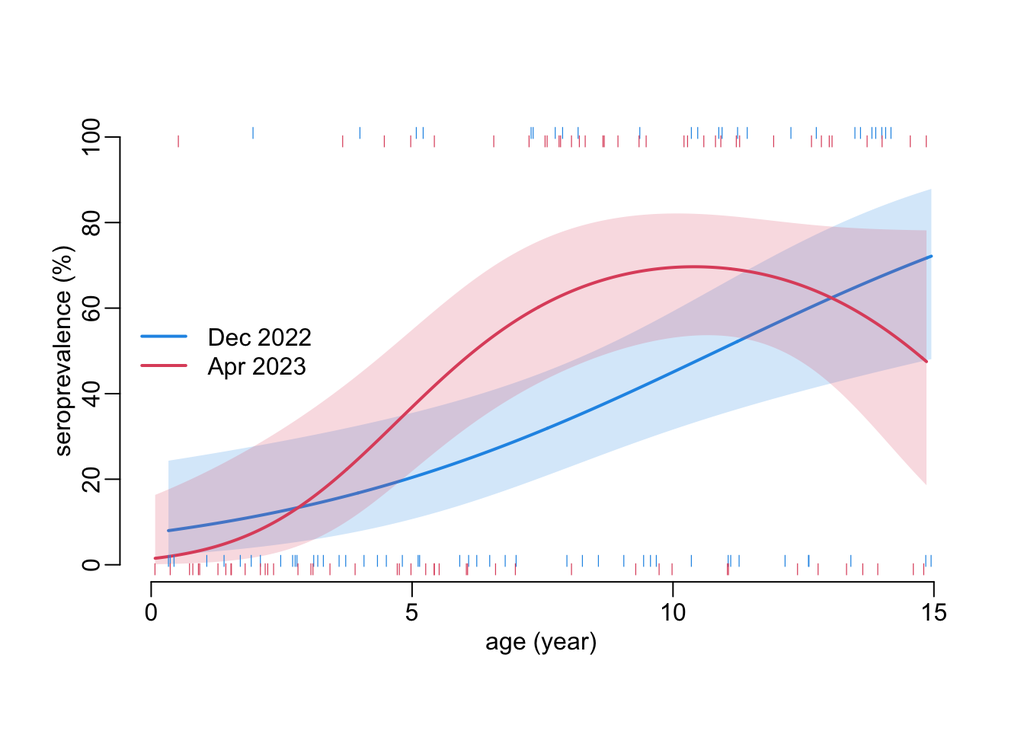

```r
m <- 100
eps <- 1

glm(neutralization ~ age, binomial, filter(sero, year == "2022")) |>
  predict2() |>
  plot_predictions()

glm(neutralization ~ age + I(age ^2), binomial, filter(sero, year == "2023")) |>
  predict2() |>
  plot_predictions(add = TRUE, col = 2)

sero |>
  filter(year == "2022") |>
  with(points2(age, m * neutralization + eps, col = 4))

sero |>
  filter(year == "2023") |>
  with(points2(age, m * neutralization - eps, col = 2))

legend("left", legend = c("Dec 2022", "Apr 2023"), lty = 1, lwd = 2,
       col = c(4, 2), bty = "n")
```

## Generalized additive model

The list of smoothing options:

```r
smooths  <- c("tp", "ds", "cr", "cs", "cc", "bs", "ps", "cp", "re", "gp", "ad",
              "sz", "fs")
```

Looking at year and smoothed age effects for all the different types of smoothing available:

```r
smooths |>
  map_dfr(~ p_values(anova(gam(neutralization ~ s(age, bs = .x) + year,
                               binomial, sero)))) |>
  add_smooth_col(smooths)
```

```
## # A tibble: 13 × 3
##    smooth  year    `s(age)`
##    <chr>  <dbl>       <dbl>
##  1 tp     0.168 0.0000311
##  2 ds     0.168 0.0000322
##  3 cr     0.169 0.0000310
##  4 cs     0.171 0.00000231
##  5 cc     0.212 0.00000635
##  6 bs     0.168 0.0000304
##  7 ps     0.168 0.0000281
##  8 cp     0.156 0.000144
##  9 re     0.169 0.000000898
## 10 gp     0.170 0.0000297
## 11 ad     0.159 0.000610
## 12 sz     0.168 0.0000311
## 13 fs     0.168 0.0000311
```

Looking at the model qualities of the different smootings options:

```r
smooths |>
  map_dfr(~ quality(gam(neutralization ~ s(age, bs = .x) + year,
                        binomial, sero))) |>
  add_smooth_col(smooths)
```

```
## # A tibble: 13 × 4
##    smooth deviance   AIC   GCV
##    <chr>     <dbl> <dbl> <dbl>
##  1 tp         166.  174. 0.163
##  2 ds         166.  174. 0.162
##  3 cr         166.  174. 0.162
##  4 cs         166.  174. 0.163
##  5 cc         165.  178. 0.186
##  6 bs         166.  174. 0.163
##  7 ps         166.  174. 0.162
##  8 cp         153.  173. 0.155
##  9 re         173.  179. 0.193
## 10 gp         166.  175. 0.163
## 11 ad         152.  174. 0.158
## 12 sz         166.  174. 0.163
## 13 fs         166.  174. 0.163
```

Models qualities for the 2 years separately:

```r
smooths |>
  map_dfr(~ quality(gam(neutralization ~ s(age, bs = .x), binomial,
                        filter(sero, year == "2022")))) |>
  add_smooth_col(smooths)
```

```
## # A tibble: 13 × 4
##    smooth deviance   AIC    GCV
##    <chr>     <dbl> <dbl>  <dbl>
##  1 tp        79.0   83.0  0.169
##  2 ds        79.0   83.0  0.169
##  3 cr        79.0   83.0  0.169
##  4 cs        79.0   83.2  0.171
##  5 cc        81.7   88.7  0.249
##  6 bs        79.0   83.0  0.169
##  7 ps        79.0   83.0  0.169
##  8 cp        80.6   88.5  0.246
##  9 re        79.0   82.9  0.167
## 10 gp        79.0   83.0  0.169
## 11 ad         9.08  60.1 -0.153
## 12 sz        79.0   83.0  0.169
## 13 fs        79.0   83.0  0.169
```

```r
smooths |>
  map_dfr(~ quality(gam(neutralization ~ s(age, bs = .x), binomial,
                        filter(sero, year == "2023")))) |>
  add_smooth_col(smooths)
```

```
## # A tibble: 13 × 4
##    smooth deviance   AIC   GCV
##    <chr>     <dbl> <dbl> <dbl>
##  1 tp         85.1  91.9 0.163
##  2 ds         85.1  91.9 0.163
##  3 cr         85.1  91.9 0.163
##  4 cs         85.1  91.9 0.163
##  5 cc         85.4  92.4 0.170
##  6 bs         85.2  91.9 0.163
##  7 ps         85.2  91.8 0.163
##  8 cp         85.7  92.4 0.169
##  9 re         94.1  97.9 0.240
## 10 gp         84.9  91.8 0.162
## 11 ad         83.1  90.9 0.151
## 12 sz         85.1  91.9 0.163
## 13 fs         85.1  91.9 0.163
```

The figure with a given smoothing:

```r
gam_figure <- function(s = "bs") {
  m <- 100
  eps <- 1

  gam2(neutralization ~ s(age, bs = s), binomial,
       filter(sero, year == "2022")) |>
    predict2() |>
    plot_predictions()

  gam2(neutralization ~ s(age, bs = s), binomial,
       filter(sero, year == "2023")) |>
    predict2() |>
    plot_predictions(add = TRUE, col = 2)

  sero |>
    filter(year == "2022") |>
    with(points2(age, m * neutralization + eps, col = 4))

  sero |>
    filter(year == "2023") |>
    with(points2(age, m * neutralization - eps, col = 2))

  legend("left", legend = c("Dec 2022", "Apr 2023"), lty = 1, lwd = 2,
         col = c(4, 2), bty = "n")
}
```

With B-spline:

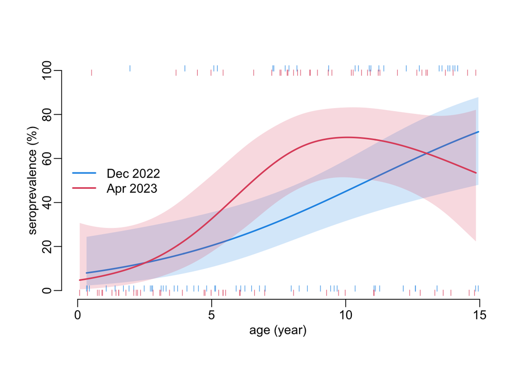

```r
gam_figure(s = "bs")
```

## Modeling age and time at the same time

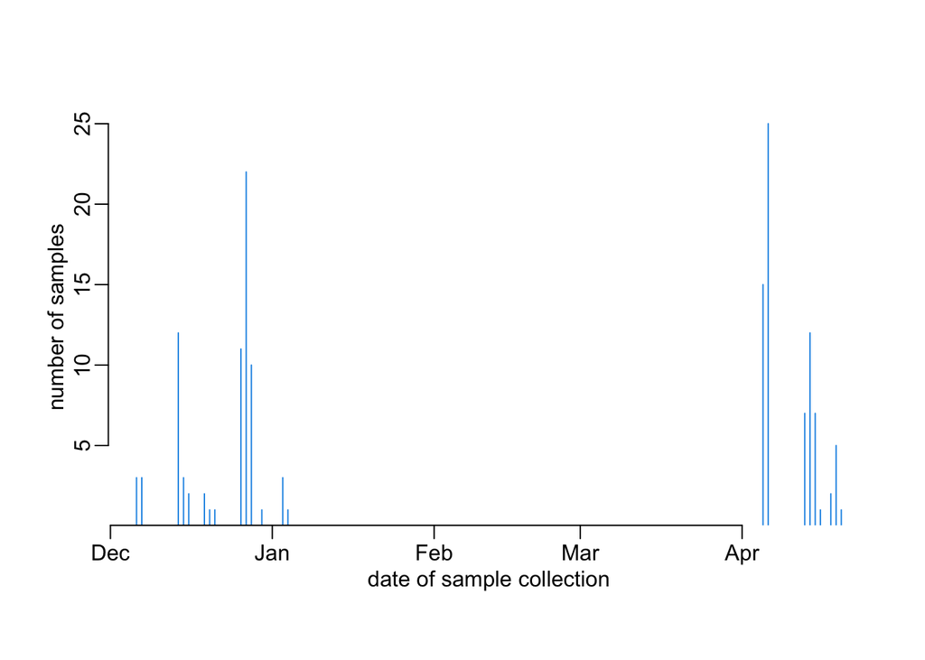

```r
sero |>
  group_by(collection_date) |>
  tally() |>
  plot(type = "h", xlab = "date of sample collection",
       ylab = "number of samples", col = 4)
```

```r
sero |>
  select(age, neutralization, collection_date)
```

```
## # A tibble: 150 × 3
##       age neutralization collection_date
##     <dbl> <lgl>          <date>
##  1 0.370  FALSE          2022-12-28
##  2 0.332  FALSE          2022-12-27
##  3 0.0767 FALSE          2023-01-04
##  4 0.438  FALSE          2022-12-27
##  5 0.932  FALSE          2023-01-03
##  6 1.96   TRUE           2022-12-26
##  7 1.40   FALSE          2022-12-26
##  8 1.07   FALSE          2022-12-27
##  9 1.71   FALSE          2022-12-06
## 10 1.92   FALSE          2022-12-27
## # ℹ 140 more rows
```

```r
mod1 <- glm(neutralization ~ age * collection_date +
              I(age ^ 2) * collection_date, binomial,
            mutate(sero, across(collection_date, as.numeric)))
mod2 <- update(mod1, . ~ . +   age     * I(collection_date ^ 2))
mod3 <- update(mod1, . ~ . + I(age ^2) * I(collection_date ^ 2))
mod4 <- update(mod2, . ~ . + I(age ^2) * I(collection_date ^ 2))

anova(mod1, mod2, mod4)
```

```
## Analysis of Deviance Table
##
## Model 1: neutralization ~ age * collection_date + I(age^2) * collection_date
## Model 2: neutralization ~ age + collection_date + I(age^2) + I(collection_date^2) +
##     age:collection_date + collection_date:I(age^2) + age:I(collection_date^2)
## Model 3: neutralization ~ age + collection_date + I(age^2) + I(collection_date^2) +
##     age:collection_date + collection_date:I(age^2) + age:I(collection_date^2) +
##     I(age^2):I(collection_date^2)
##   Resid. Df Resid. Dev Df Deviance
## 1       144     166.06
## 2       142     165.57  2  0.48713
## 3       141     165.52  1  0.05248
```

```r
anova(mod1, mod3, mod4)
```

```
## Analysis of Deviance Table
##
## Model 1: neutralization ~ age * collection_date + I(age^2) * collection_date
## Model 2: neutralization ~ age + collection_date + I(age^2) + I(collection_date^2) +
##     age:collection_date + collection_date:I(age^2) + I(age^2):I(collection_date^2)
## Model 3: neutralization ~ age + collection_date + I(age^2) + I(collection_date^2) +
##     age:collection_date + collection_date:I(age^2) + age:I(collection_date^2) +
##     I(age^2):I(collection_date^2)
##   Resid. Df Resid. Dev Df Deviance
## 1       144     166.06
## 2       142     165.67  2  0.39438
## 3       141     165.52  1  0.14523
```

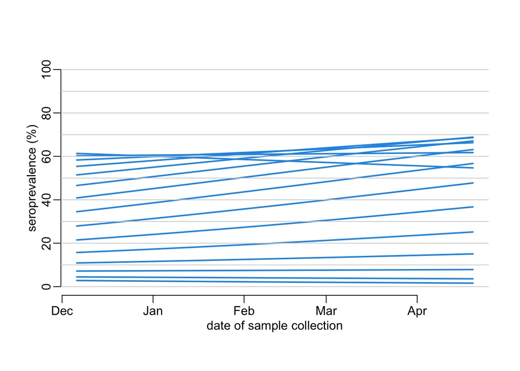

```r
x <- mod1

dataset <- x$data

age_val <- c(.1, 1:14)
collection_date_val <- seq(min(dataset$collection_date),
                           max(dataset$collection_date))

new_data <- expand.grid(age = age_val, collection_date = collection_date_val)

prdcts <- cbind(new_data, fit = 100 * predict(x, new_data, "response")) |>
  as_tibble() |>
  arrange(collection_date) |>
  mutate(across(collection_date, as_date))

prdcts |>
  filter(age == .1) |>
  with(plot(collection_date, fit, type = "l", lwd = 2, col = 4, ylim = c(0, 100),
            xlab = "date of sample collection", ylab = "seroprevalence (%)"))

walk(1:14, ~ prdcts |>
       filter(age == .x) |>
       with(lines(collection_date, fit, lwd = 2, col = 4)))

abline(h = 10 * 0:10, col = "lightgrey")
```

A 3-D version of it:

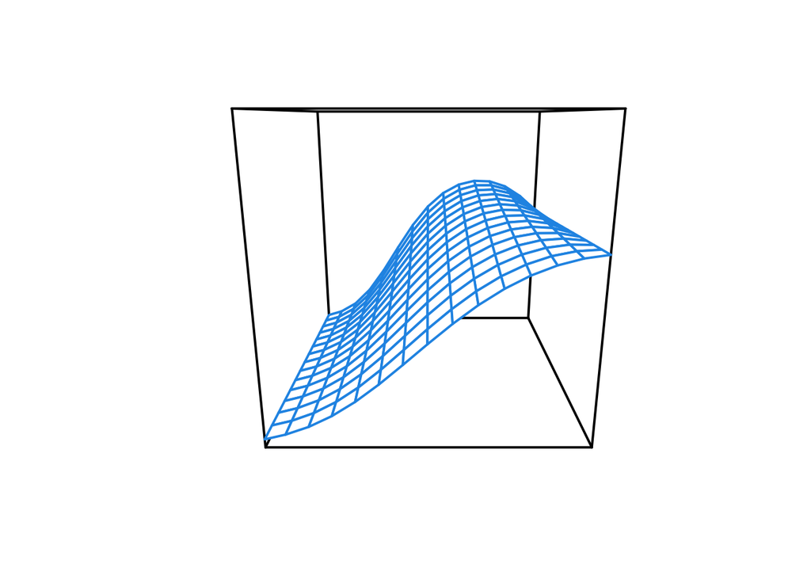

```r
x <- mod1

dataset <- x$data

age_val <- c(.1, 1:14)
collection_date_val <- seq(min(dataset$collection_date),
                           max(dataset$collection_date), le = 15)

new_data <- expand.grid(age = age_val, collection_date = collection_date_val)

prdcts <- cbind(new_data, fit = 100 * predict(x, new_data, "response")) |>
  as_tibble() |>
  arrange(collection_date) |>
  mutate(across(collection_date, as_date))

with(prdcts,
     persp(sort(unique(age)), sort(unique(collection_date)), matrix(fit, 15),
           xlab = "age (years)", ylab = "time", zlab = "seroprevalence (%)",
           zlim = c(0, 100), theta = 0, phi = 1 * 15, r = sqrt(3), d = 1,
           ticktype = "detailed", border = 4, lwd = 2, axes = FALSE))
```

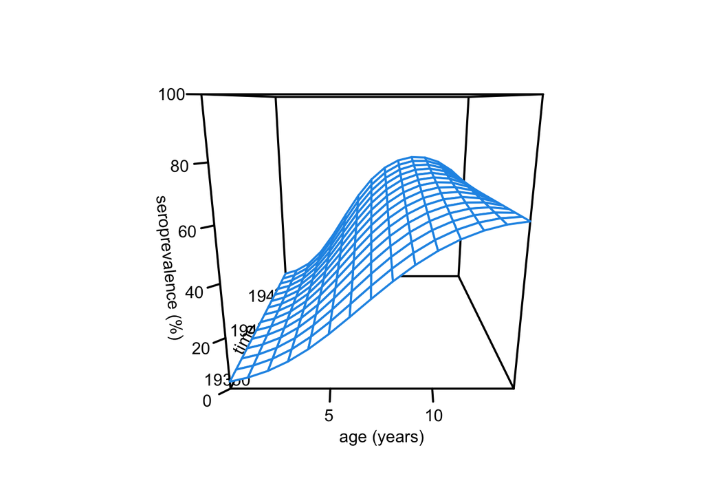

```r
with(prdcts,
     persp(sort(unique(age)), sort(unique(collection_date)), matrix(fit, 15),
           xlab = "age (years)", ylab = "time", zlab = "seroprevalence (%)",
           zlim = c(0, 100), theta = 0, phi = 1 * 15, r = sqrt(3), d = 1,
           ticktype = "detailed", border = 4, lwd = 2, axes = TRUE))
```

```r
sero |>
  group_by(year, Age_group) |>
  summarise(n = n(), mean_age = mean(age)) |>
  arrange(year, mean_age) |>
  select(- mean_age) |>
  pivot_wider(names_from = year, values_from = n) |>
  mutate(Age_group = paste0("[", str_replace(Age_group, "≤ & <", ", "), "["))
```

```
## # A tibble: 15 × 3
##    Age_group `2022` `2023`
##    <chr>      <int>  <int>
##  1 [0, 1[         3      7
##  2 [1, 2[         5      5
##  3 [2, 3[         5      5
##  4 [3, 4[         5      5
##  5 [4, 5[         5      5
##  6 [5, 6[         5      5
##  7 [6, 7[         5      5
##  8 [7, 8[         5      5
##  9 [8, 9[         3      7
## 10 [9, 10[        5      5
## 11 [10, 11[       5      5
## 12 [11, 12[       5      5
## 13 [12, 13[       5      5
## 14 [13, 14[       5      5
## 15 [14, 15[       5      5
```

## Quantitative analysis

```r
tmp <- sero |>
  filter(neutralization) |>
  select(age, year, collection_date, `Serum dilution`) |>
  rename(dilution = `Serum dilution`) |>
  filter(! is.na(dilution))
```

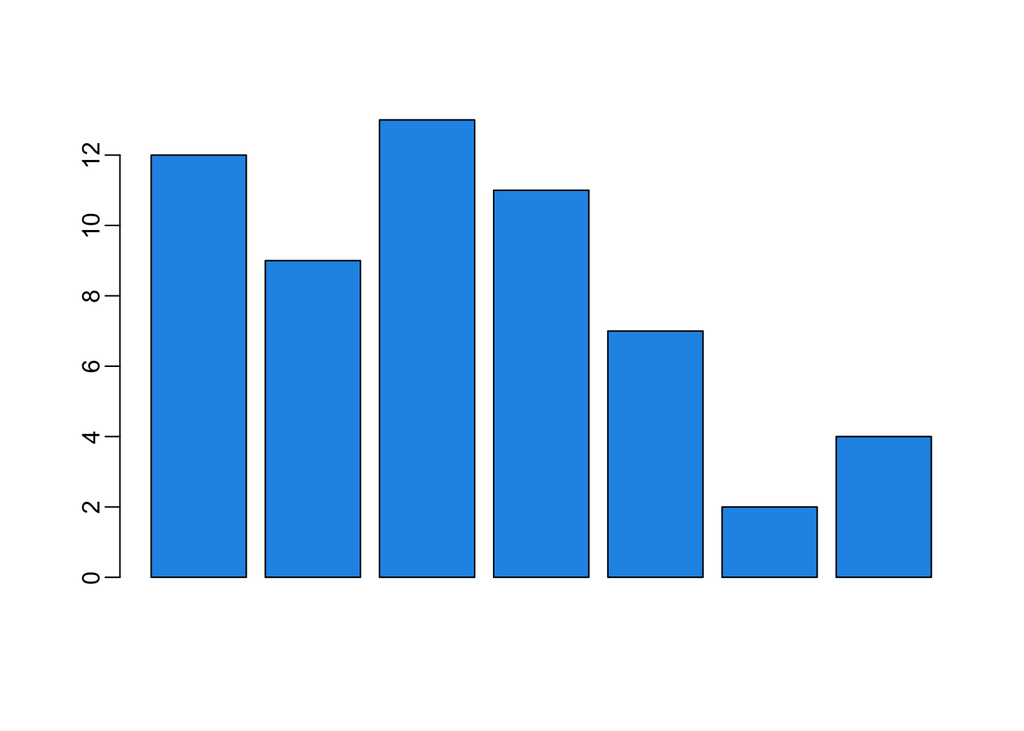

```r
tmp |>
  group_by(dilution) |>
  tally() |>
  mutate(dilution = log2(dilution)) |>
  with(barplot(n, col = 4))
```

```r
tmp2 <- tmp |>
  mutate(dilution = log2(dilution))
```

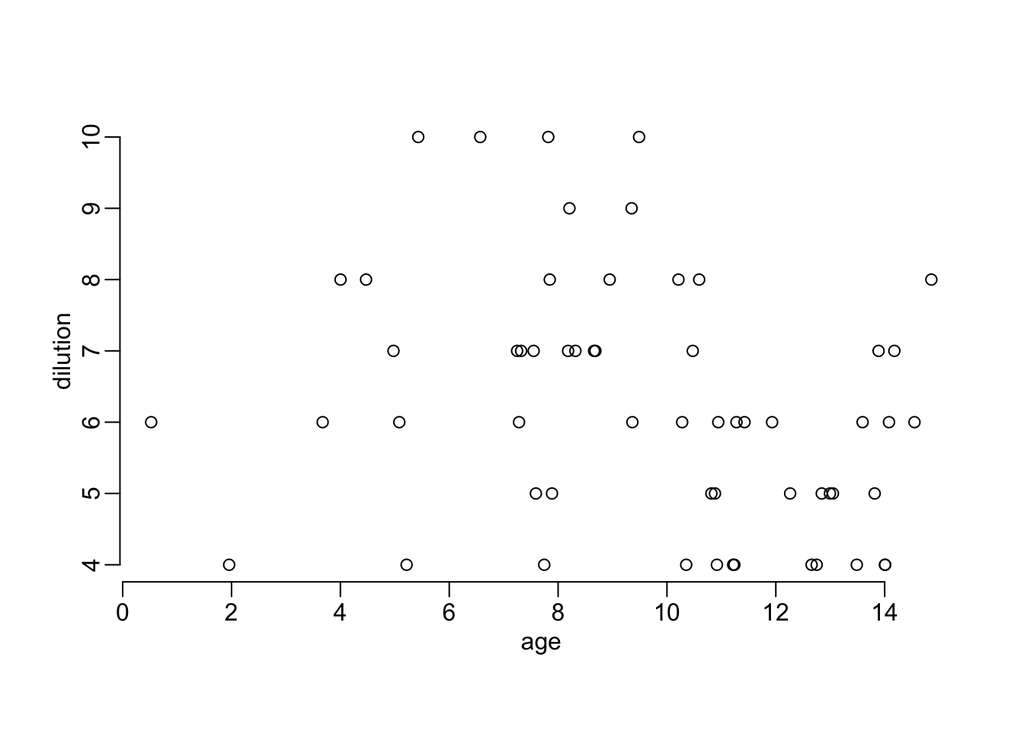

```r
with(tmp2, plot(age, dilution))
```

```r
lrt(glm(dilution ~ age + I(age^2) + I(age^3) + I(age^4), gaussian, tmp2))
```

```
## Analysis of Deviance Table
##
## Model: gaussian, link: identity
##
## Response: dilution
##
## Terms added sequentially (first to last)
##
##
##          Df Deviance Resid. Df Resid. Dev Pr(>Chi)
## NULL                        57     174.62
## age       1  14.4096        56     160.21 0.012526 *
## I(age^2)  1   9.6905        55     150.52 0.040594 *
## I(age^3)  1  11.1150        54     139.41 0.028307 *
## I(age^4)  1  16.9144        53     122.49 0.006825 **
## ---
## Signif. codes:  0 '***' 0.001 '**' 0.01 '*' 0.05 '.' 0.1 ' ' 1
```

```r
lrt(glm(dilution ~ age*as.factor(year) + I(age^2)*as.factor(year), gaussian, tmp2))
```

```
## Analysis of Deviance Table
##
## Model: gaussian, link: identity
##
## Response: dilution
##
## Terms added sequentially (first to last)
##
##
##                          Df Deviance Resid. Df Resid. Dev Pr(>Chi)
## NULL                                        57     174.62
## age                       1  14.4096        56     160.21  0.01261 *
## as.factor(year)           1  21.7296        55     138.48  0.00219 **
## I(age^2)                  1   7.0060        54     131.47  0.08197 .
## age:as.factor(year)       1   8.3773        53     123.10  0.05718 .
## as.factor(year):I(age^2)  1   2.6769        52     120.42  0.28231
## ---
## Signif. codes:  0 '***' 0.001 '**' 0.01 '*' 0.05 '.' 0.1 ' ' 1
```

```r
model <- glm(dilution ~ age + as.factor(year), gaussian, tmp2)

lrt(model)
```

```
## Analysis of Deviance Table
##
## Model: gaussian, link: identity
##
## Response: dilution
##
## Terms added sequentially (first to last)
##
##
##                 Df Deviance Resid. Df Resid. Dev Pr(>Chi)
## NULL                               57     174.62
## age              1    14.41        56     160.21 0.016744 *
## as.factor(year)  1    21.73        55     138.48 0.003306 **
## ---
## Signif. codes:  0 '***' 0.001 '**' 0.01 '*' 0.05 '.' 0.1 ' ' 1
```

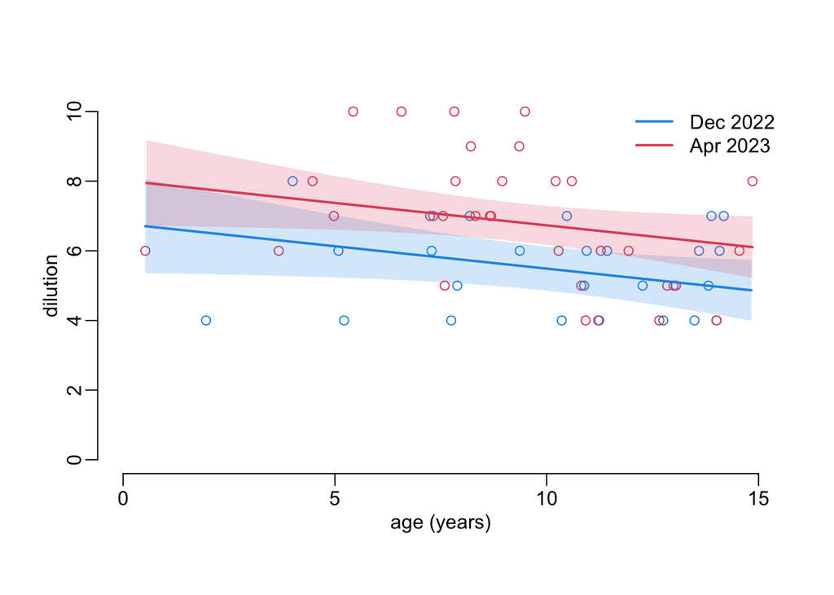

```r
ages <- seq(min(tmp2$age), max(tmp2$age), le = 512)
new_data <- data.frame(age = ages, year = 2022:2023)
prdcts <- predict(model, new_data, se.fit = TRUE)

prdcts <- as_tibble(prdcts[-3]) |>
  mutate(lwr = fit + qt(.025, nrow(tmp2) - 1) * se.fit,
         upr = fit + qt(.975, nrow(tmp2) - 1) * se.fit)

prdcts <- cbind(new_data, prdcts) |>
  as_tibble()

plot(NA, xlim = c(0, 15), ylim = c(0, 10), xlab = "age (years)", ylab = "dilution")

tmp2 |>
  filter(year == 2022) |>
  with(points(age, dilution, col = 4))

tmp2 |>
  filter(year == 2023) |>
  with(points(age, dilution, col = 2))

prdcts |>
  filter(year == 2022) |>
  with({
    polygon2(age, lwr, upr, col = adjustcolor(4, .2), border = NA)
    lines(age, fit, col = 4, lwd = 2)
  })

prdcts |>
  filter(year == 2023) |>
  with({
    polygon2(age, lwr, upr, col = adjustcolor(2, .2), border = NA)
    lines(age, fit, col = 2, lwd = 2)
  })

legend("topright", legend = c("Dec 2022", "Apr 2023"), lty = 1, lwd = 2,
         col = c(4, 2), bty = "n")
```